# Part II - Ford GoBike System Data Exploration

## Dataset Overview

> The dataset consisted of 183412 rows and 16 columns. After prelimiary wrangling and feature engineering we are now left with (172207 bike rides that occurred in the year 2019 with 20 features(duration_sec, start_time, end_time, start_station_id, start_station_name, start_station_latitude, start_station_longitude, end_station_id, end_station_name, end_station_latitude, end_station_longitude, bike_id, user_type, member_birth_year, member_gender, bike_share_for_all_trip, day, month, member_age, distance_km).

## Distribution of Bike rides in trip duration(sec)

> Initially duration_sec had a long-tailed distribution with very few rides at the high end duration. When plotted on a log-scale, most trip duration occured in less than 33mins 20 secs (2000 seconds ). The highest record of trips occured in 10mins (600 secs). The number of trips initially increases from around 8000 values at 0 to 12000 values at around 600 seconds, but then begins to fall, reaching below 2000 values in less than 33 minutes

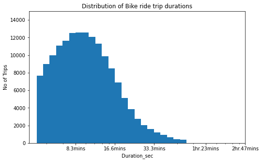

## Relationship between distance(km) covered and trip duration(sec)

> The regression line in the scatter plot shows a positive correlation bwtween distance covered and duration

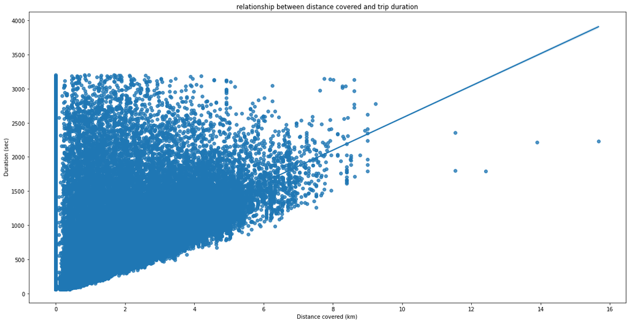

## Bike usage distribution by Weekday

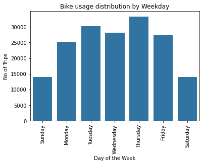